# Diabete_data_report

Franklin

7/26/2017

## Report

First I want to look at the general summary of the data, so I have a better sense of direction of how to explore the data.

```r
summary(data)
```

```
##   Pregnancies        Glucose      BloodPressure    SkinThickness
##  Min.   : 0.000   Min.   :  0.0   Min.   :  0.00   Min.   : 0.00
##  1st Qu.: 1.000   1st Qu.: 99.0   1st Qu.: 62.00   1st Qu.: 0.00
##  Median : 3.000   Median :117.0   Median : 72.00   Median :23.00
##  Mean   : 3.845   Mean   :120.9   Mean   : 69.11   Mean   :20.54
##  3rd Qu.: 6.000   3rd Qu.:140.2   3rd Qu.: 80.00   3rd Qu.:32.00
##  Max.   :17.000   Max.   :199.0   Max.   :122.00   Max.   :99.00
##     Insulin           BMI        DiabetesPedigreeFunction      Age
##  Min.   :  0.0   Min.   : 0.00   Min.   :0.0780           Min.   :21.00
##  1st Qu.:  0.0   1st Qu.:27.30   1st Qu.:0.2437           1st Qu.:24.00
##  Median : 30.5   Median :32.00   Median :0.3725           Median :29.00
##  Mean   : 79.8   Mean   :31.99   Mean   :0.4719           Mean   :33.24
##  3rd Qu.:127.2   3rd Qu.:36.60   3rd Qu.:0.6262           3rd Qu.:41.00
##  Max.   :846.0   Max.   :67.10   Max.   :2.4200           Max.   :81.00
##     Outcome
##  Min.   :0.000
##  1st Qu.:0.000
##  Median :0.000
##  Mean   :0.349
##  3rd Qu.:1.000
##  Max.   :1.000
```

I am going to split data into training set and test set. Then build a model on traning data to test on test data.

```r
splitData <- resample_partition(data, c(test = 0.3, train = 0.7))


fit <- rpart(Outcome ~ Pregnancies + Glucose + BloodPressure + SkinThickness
                 + DiabetesPedigreeFunction + Age,control = 6, data = splitData$train)

mae(model = fit, data = splitData$test)
```

```
## [1] 0.3355527
```

```r
print(head(predict(fit, splitData$test)))
```

```
##          6          7          8         12         21         23
## 0.59375000 0.08900524 0.08900524 0.81927711 0.48000000 0.81927711
```

```r
pred_outcome <- predict(fit, splitData$test)

pred_outcome[which(pred_outcome[]>=0.5)] <- 1
pred_outcome[which(pred_outcome[]<=0.5)] <- 0

actual <- as.data.frame(splitData$test)$Outcome

result <- vector("numeric")

for(i in 1 : length(actual)){

  result[i]<-pred_outcome[i]==actual[i]

}

accuracy <- table(result)

accuracy[2] / (accuracy[1] + accuracy[2] )
```

```
##   1
## 0.7
```

```r
target <- "Outcome"
predictors <-  c("Pregnancies","Glucose","BloodPressure","SkinThickness",
                 "Insulin","Age","BMI")

get_mae <- function(maxdepth, target, predictors, training_data, testing_data){

  # turn the predictors & target into a formula to pass to rpart()
  predictors <- paste(predictors, collapse="+")
  formula <- as.formula(paste(target,"~",predictors,sep = ""))

  # build our model
  model <- rpart(formula, data = training_data,
                 control = rpart.control(maxdepth = maxdepth))
  # get the mae
  pred_outcome <- predict(model, testing_data)

  pred_outcome[which(pred_outcome[]>=0.5)] <- 1
  pred_outcome[which(pred_outcome[]<=0.5)] <- 0

  actual <- as.data.frame(testing_data)$Outcome

  result <- vector("numeric")

for(i in 1 : length(actual)){

  result[i]<-pred_outcome[i]==actual[i]

}

accuracy <- table(result)


  return(accuracy[2] / (accuracy[1] + accuracy[2] ))
}

for(i in 1:10){
  mae <- get_mae(maxdepth = i, target = target, predictors = predictors,
                 training_data = splitData$train, testing_data = splitData$test)
  print(glue::glue("Maxdepth: ",i,"\t accuracy: ",mae))
}
```

```
## Maxdepth: 1   accuracy: c(`1` = 0.756521739130435)
## Maxdepth: 2   accuracy: c(`1` = 0.756521739130435)
## Maxdepth: 3   accuracy: c(`1` = 0.734782608695652)
## Maxdepth: 4   accuracy: c(`1` = 0.717391304347826)
## Maxdepth: 5   accuracy: c(`1` = 0.717391304347826)
## Maxdepth: 6   accuracy: c(`1` = 0.717391304347826)
## Maxdepth: 7   accuracy: c(`1` = 0.717391304347826)
## Maxdepth: 8   accuracy: c(`1` = 0.717391304347826)
## Maxdepth: 9   accuracy: c(`1` = 0.717391304347826)
## Maxdepth: 10  accuracy: c(`1` = 0.717391304347826)
```

I changed the number into 1 or 0 if the predicted outcome is higher or lower than 0.5 and check the accuracy. And the accuracy of our model is shown above.

## Plots

Now I want to visually see my data to have a better sense of it.

Frist, I want to see how the variable interact with the outcome.

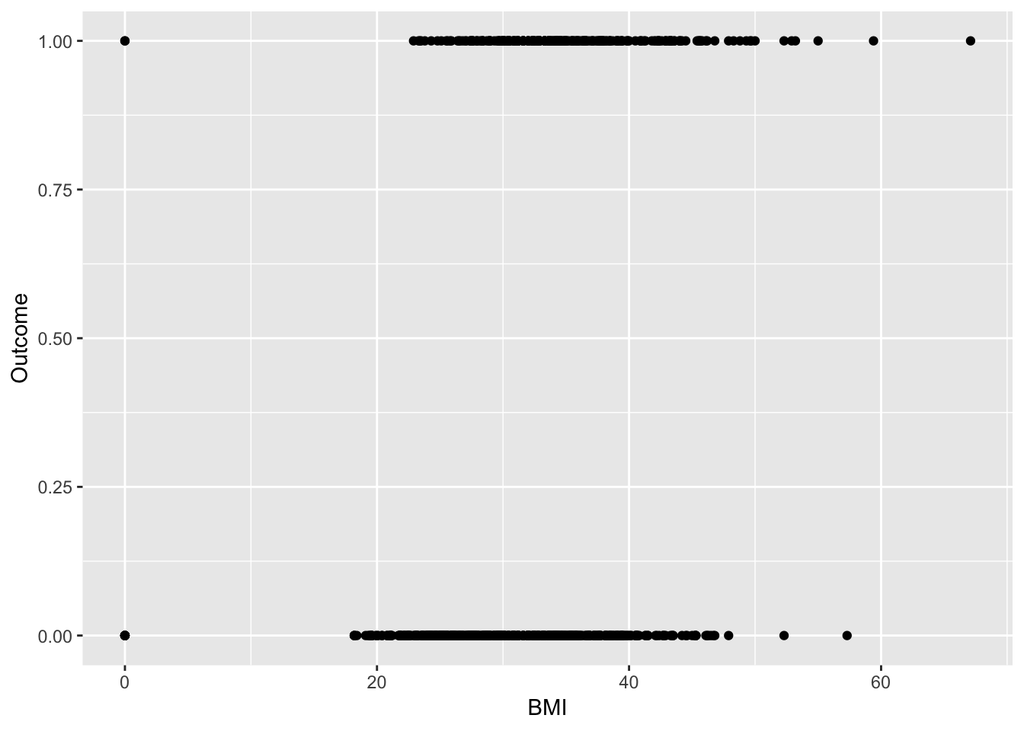

```r
ggplot(data = data, aes(x = BMI, y = Outcome)) +
  geom_point()
```

However, it does not seem to tell me anything. I will try out other variables.

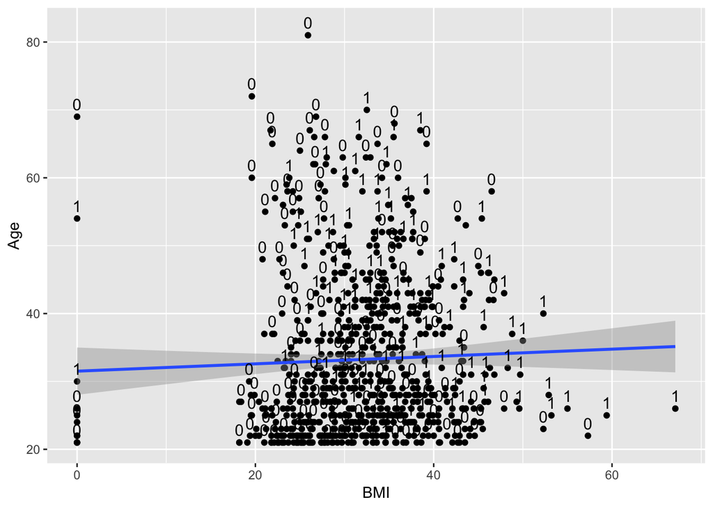

```r
ggplot(data = data, aes(x = BMI, y = Age, label = Outcome)) +
  geom_point() +
  geom_smooth(method = "lm") +
      geom_text(check_overlap = T,
              vjust = "bottom", # adjust the vertical orientation
              nudge_y = 1, # move the text up a bit

              size = 4 # make the text smaller (to reduce overlap more)
             ) #
```

It does not seem to have a strong linear relationship.